# BOSTON HOUSING DATA EXPLORATION

```python
import pandas as pd
import numpy as np
import matplotlib.pyplot as plt
import seaborn as sns
```

```python
df = pd.read_csv(r"housing.csv")
df
```

|  | 0.00632 18.00 2.310 0 0.5380 6.5750 65.20 4.0900 1 296.0 15.30 396.90 4.98 24.00 |
| --- | --- |
| 0 | 0.02731 0.00 7.070 0 0.4690 6.4210 78... |
| 1 | 0.02729 0.00 7.070 0 0.4690 7.1850 61... |
| 2 | 0.03237 0.00 2.180 0 0.4580 6.9980 45... |
| 3 | 0.06905 0.00 2.180 0 0.4580 7.1470 54... |
| 4 | 0.02985 0.00 2.180 0 0.4580 6.4300 58... |
| ... | ... |
| 500 | 0.06263 0.00 11.930 0 0.5730 6.5930 69... |
| 501 | 0.04527 0.00 11.930 0 0.5730 6.1200 76... |
| 502 | 0.06076 0.00 11.930 0 0.5730 6.9760 91... |
| 503 | 0.10959 0.00 11.930 0 0.5730 6.7940 89... |
| 504 | 0.04741 0.00 11.930 0 0.5730 6.0300 80... |

505 rows × 1 columns

### ORGANIZING THE DATA

```python
col_names = ['CRIM', 'ZN', 'INDUS', 'CHAS', 'NOX', 'RM', 'AGE', 'DIS','RAD', 'TAX', 'PTRATIO', 'B', 'LSTAT', 'MEDV']
df = pd.read_csv(r'housing.csv', delimiter=r'\s+', names = col_names)
```

```python
df
```

|  | CRIM | ZN | INDUS | CHAS | NOX | RM | AGE | DIS | RAD | TAX | PTRATIO | B | LSTAT | MEDV |
| --- | --- | --- | --- | --- | --- | --- | --- | --- | --- | --- | --- | --- | --- | --- |
| 0 | 0.00632 | 18.0 | 2.31 | 0 | 0.538 | 6.575 | 65.2 | 4.0900 | 1 | 296.0 | 15.3 | 396.90 | 4.98 | 24.0 |
| 1 | 0.02731 | 0.0 | 7.07 | 0 | 0.469 | 6.421 | 78.9 | 4.9671 | 2 | 242.0 | 17.8 | 396.90 | 9.14 | 21.6 |
| 2 | 0.02729 | 0.0 | 7.07 | 0 | 0.469 | 7.185 | 61.1 | 4.9671 | 2 | 242.0 | 17.8 | 392.83 | 4.03 | 34.7 |
| 3 | 0.03237 | 0.0 | 2.18 | 0 | 0.458 | 6.998 | 45.8 | 6.0622 | 3 | 222.0 | 18.7 | 394.63 | 2.94 | 33.4 |
| 4 | 0.06905 | 0.0 | 2.18 | 0 | 0.458 | 7.147 | 54.2 | 6.0622 | 3 | 222.0 | 18.7 | 396.90 | 5.33 | 36.2 |
| ... | ... | ... | ... | ... | ... | ... | ... | ... | ... | ... | ... | ... | ... | ... |
| 501 | 0.06263 | 0.0 | 11.93 | 0 | 0.573 | 6.593 | 69.1 | 2.4786 | 1 | 273.0 | 21.0 | 391.99 | 9.67 | 22.4 |
| 502 | 0.04527 | 0.0 | 11.93 | 0 | 0.573 | 6.120 | 76.7 | 2.2875 | 1 | 273.0 | 21.0 | 396.90 | 9.08 | 20.6 |
| 503 | 0.06076 | 0.0 | 11.93 | 0 | 0.573 | 6.976 | 91.0 | 2.1675 | 1 | 273.0 | 21.0 | 396.90 | 5.64 | 23.9 |
| 504 | 0.10959 | 0.0 | 11.93 | 0 | 0.573 | 6.794 | 89.3 | 2.3889 | 1 | 273.0 | 21.0 | 393.45 | 6.48 | 22.0 |
| 505 | 0.04741 | 0.0 | 11.93 | 0 | 0.573 | 6.030 | 80.8 | 2.5050 | 1 | 273.0 | 21.0 | 396.90 | 7.88 | 11.9 |

506 rows × 14 columns

```python
df.head(10)
```

|  | CRIM | ZN | INDUS | CHAS | NOX | RM | AGE | DIS | RAD | TAX | PTRATIO | B | LSTAT | MEDV |
| --- | --- | --- | --- | --- | --- | --- | --- | --- | --- | --- | --- | --- | --- | --- |
| 0 | 0.00632 | 18.0 | 2.31 | 0 | 0.538 | 6.575 | 65.2 | 4.0900 | 1 | 296.0 | 15.3 | 396.90 | 4.98 | 24.0 |
| 1 | 0.02731 | 0.0 | 7.07 | 0 | 0.469 | 6.421 | 78.9 | 4.9671 | 2 | 242.0 | 17.8 | 396.90 | 9.14 | 21.6 |
| 2 | 0.02729 | 0.0 | 7.07 | 0 | 0.469 | 7.185 | 61.1 | 4.9671 | 2 | 242.0 | 17.8 | 392.83 | 4.03 | 34.7 |
| 3 | 0.03237 | 0.0 | 2.18 | 0 | 0.458 | 6.998 | 45.8 | 6.0622 | 3 | 222.0 | 18.7 | 394.63 | 2.94 | 33.4 |
| 4 | 0.06905 | 0.0 | 2.18 | 0 | 0.458 | 7.147 | 54.2 | 6.0622 | 3 | 222.0 | 18.7 | 396.90 | 5.33 | 36.2 |
| 5 | 0.02985 | 0.0 | 2.18 | 0 | 0.458 | 6.430 | 58.7 | 6.0622 | 3 | 222.0 | 18.7 | 394.12 | 5.21 | 28.7 |
| 6 | 0.08829 | 12.5 | 7.87 | 0 | 0.524 | 6.012 | 66.6 | 5.5605 | 5 | 311.0 | 15.2 | 395.60 | 12.43 | 22.9 |
| 7 | 0.14455 | 12.5 | 7.87 | 0 | 0.524 | 6.172 | 96.1 | 5.9505 | 5 | 311.0 | 15.2 | 396.90 | 19.15 | 27.1 |
| 8 | 0.21124 | 12.5 | 7.87 | 0 | 0.524 | 5.631 | 100.0 | 6.0821 | 5 | 311.0 | 15.2 | 386.63 | 29.93 | 16.5 |
| 9 | 0.17004 | 12.5 | 7.87 | 0 | 0.524 | 6.004 | 85.9 | 6.5921 | 5 | 311.0 | 15.2 | 386.71 | 17.10 | 18.9 |

### DATA PROCESSING

```python
df.dtypes
```

```
CRIM       float64
ZN         float64
INDUS      float64
CHAS         int64
NOX        float64
RM         float64
AGE        float64
DIS        float64
RAD          int64
TAX        float64
PTRATIO    float64
B          float64
LSTAT      float64
MEDV       float64
dtype: object
```

```python
df.nunique()
```

```
CRIM       504
ZN          26
INDUS       76
CHAS         2
NOX         81
RM         446
AGE        356
DIS        412
RAD          9
TAX         66
PTRATIO     46
B          357
LSTAT      455
MEDV       229
dtype: int64
```

```python
df.size
```

```
7084
```

```python
df.shape
```

```
(506, 14)
```

```python
df.isnull().sum()
```

```
CRIM       0
ZN         0
INDUS      0
CHAS       0
NOX        0
RM         0
AGE        0
DIS        0
RAD        0
TAX        0
PTRATIO    0
B          0
LSTAT      0
MEDV       0
dtype: int64
```

```python
df.info()
```

```
<class 'pandas.core.frame.DataFrame'>
RangeIndex: 506 entries, 0 to 505
Data columns (total 14 columns):
 #   Column   Non-Null Count  Dtype
---  ------   --------------  -----
 0   CRIM     506 non-null    float64
 1   ZN       506 non-null    float64
 2   INDUS    506 non-null    float64
 3   CHAS     506 non-null    int64
 4   NOX      506 non-null    float64
 5   RM       506 non-null    float64
 6   AGE      506 non-null    float64
 7   DIS      506 non-null    float64
 8   RAD      506 non-null    int64
 9   TAX      506 non-null    float64
 10  PTRATIO  506 non-null    float64
 11  B        506 non-null    float64
 12  LSTAT    506 non-null    float64
 13  MEDV     506 non-null    float64
dtypes: float64(12), int64(2)
memory usage: 55.5 KB
```

```python
df.describe()
```

|  | CRIM | ZN | INDUS | CHAS | NOX | RM | AGE | DIS | RAD | TAX | PTRATIO | B | LSTAT | MEDV |
| --- | --- | --- | --- | --- | --- | --- | --- | --- | --- | --- | --- | --- | --- | --- |
| count | 506.000000 | 506.000000 | 506.000000 | 506.000000 | 506.000000 | 506.000000 | 506.000000 | 506.000000 | 506.000000 | 506.000000 | 506.000000 | 506.000000 | 506.000000 | 506.000000 |
| mean | 3.613524 | 11.363636 | 11.136779 | 0.069170 | 0.554695 | 6.284634 | 68.574901 | 3.795043 | 9.549407 | 408.237154 | 18.455534 | 356.674032 | 12.653063 | 22.532806 |
| std | 8.601545 | 23.322453 | 6.860353 | 0.253994 | 0.115878 | 0.702617 | 28.148861 | 2.105710 | 8.707259 | 168.537116 | 2.164946 | 91.294864 | 7.141062 | 9.197104 |
| min | 0.006320 | 0.000000 | 0.460000 | 0.000000 | 0.385000 | 3.561000 | 2.900000 | 1.129600 | 1.000000 | 187.000000 | 12.600000 | 0.320000 | 1.730000 | 5.000000 |
| 25% | 0.082045 | 0.000000 | 5.190000 | 0.000000 | 0.449000 | 5.885500 | 45.025000 | 2.100175 | 4.000000 | 279.000000 | 17.400000 | 375.377500 | 6.950000 | 17.025000 |
| 50% | 0.256510 | 0.000000 | 9.690000 | 0.000000 | 0.538000 | 6.208500 | 77.500000 | 3.207450 | 5.000000 | 330.000000 | 19.050000 | 391.440000 | 11.360000 | 21.200000 |
| 75% | 3.677083 | 12.500000 | 18.100000 | 0.000000 | 0.624000 | 6.623500 | 94.075000 | 5.188425 | 24.000000 | 666.000000 | 20.200000 | 396.225000 | 16.955000 | 25.000000 |
| max | 88.976200 | 100.000000 | 27.740000 | 1.000000 | 0.871000 | 8.780000 | 100.000000 | 12.126500 | 24.000000 | 711.000000 | 22.000000 | 396.900000 | 37.970000 | 50.000000 |

### EXPLORATORY DATA ANALYSIS

##### UNIMODEL DATA VISUALIZATION

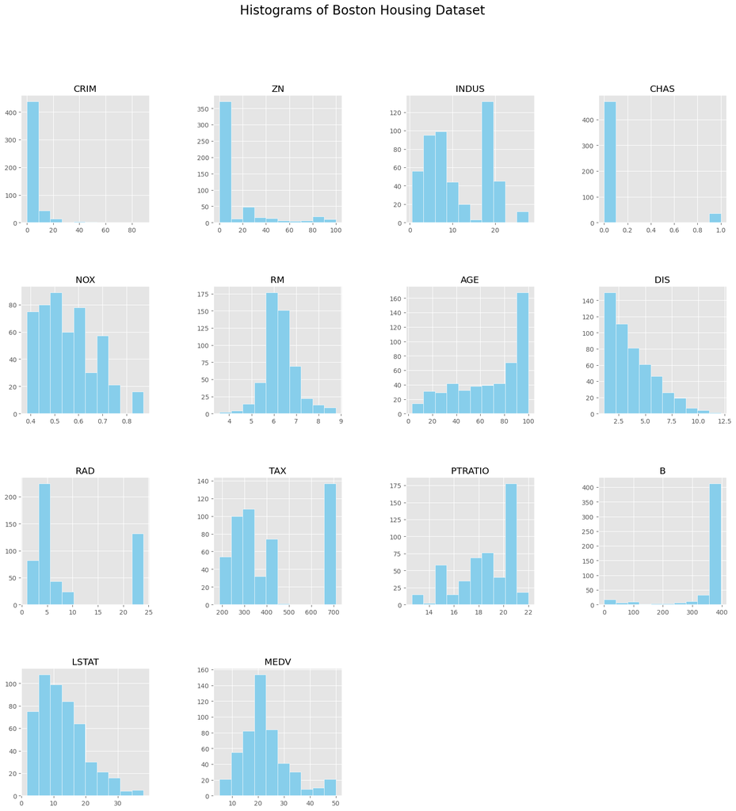

```python
plt.style.use('ggplot')
df.hist(figsize=(20,20), color = 'skyblue', edgecolor = 'white')

plt.suptitle("Histograms of Boston Housing Dataset", fontsize=20)
plt.xlabel("Variable Name", fontsize=15)
plt.ylabel("Frequency", fontsize=15)
plt.xticks(fontsize=12)
plt.yticks(fontsize=12)
plt.subplots_adjust(hspace=0.5, wspace=0.5)
plt.show()
```

##### BIVARIATE VARIALE VISUALIZATION

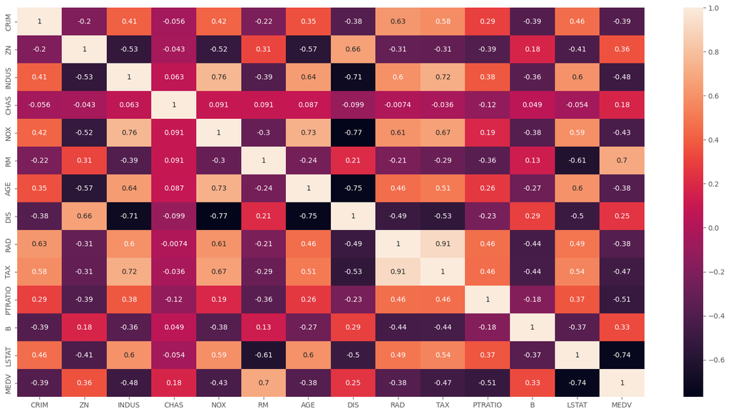

```python
plt.figure(figsize = (20,10))
sns.heatmap(df.corr(), annot = True)
```

Observations: 1) By looking at the correlation matrix we can see that RM has a strong positive correlation with MEDV (0.7) where as LSAT has a high negative correlation with MEDV(-0.74).

2) Based on the above observations we will RM and LSAT as our features. Using a scatter plot let’s see how these features vary with MEDV.

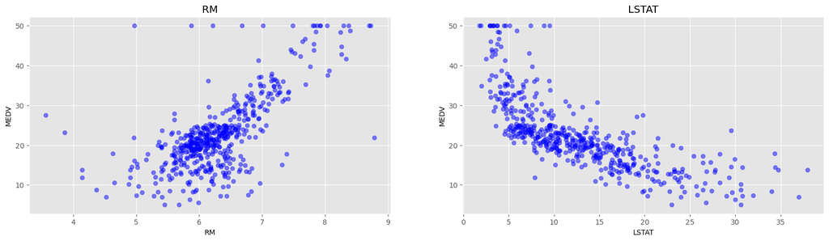

```python
plt.figure(figsize=(20, 5))

a = ['RM', 'LSTAT']
b = df['MEDV']

for i, col in enumerate(a):
    plt.subplot(1, len(a) , i+1)
    x = df[col]
    y = b
    plt.scatter(x, y, marker='o', color = 'b', alpha = 0.5)
    plt.title(col)
    plt.xlabel(col)
    plt.ylabel('MEDV')
```

Observations: 1) The prices increase as the value of RM increases linearly. There are few outliers and the data seems to be capped at 50. 2) The prices tend to decrease with an increase in LSTAT. Though it doesn’t look to be following exactly a linear line.

##### IDENTIFYING OUTLIERS

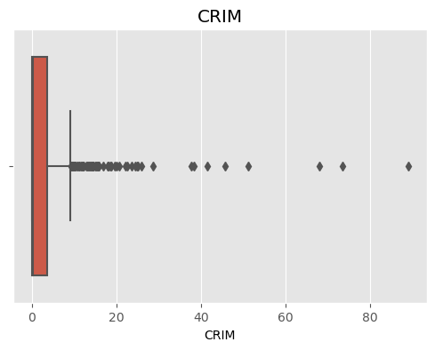

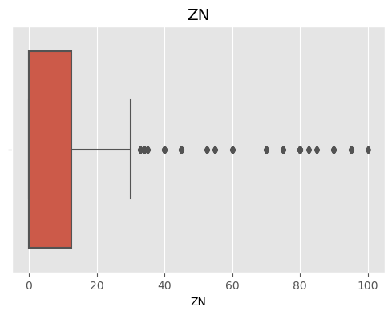

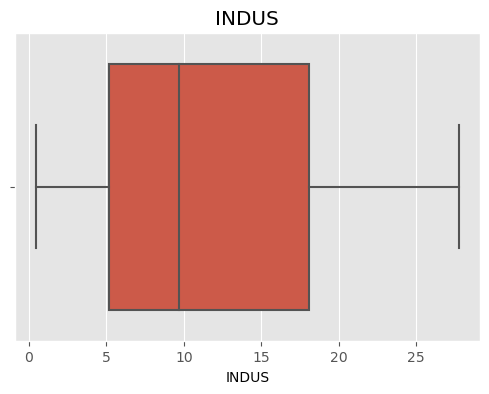

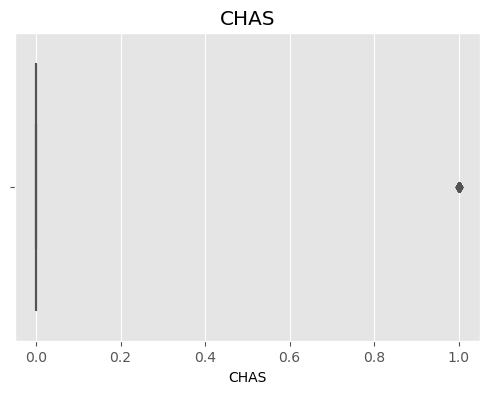

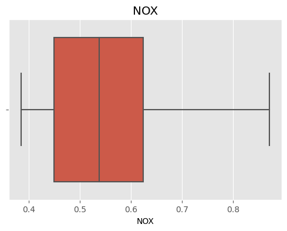

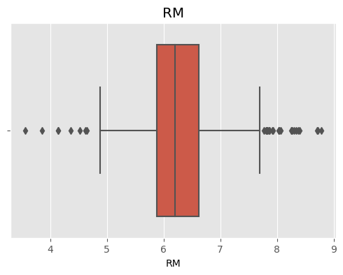

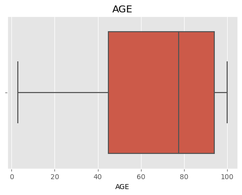

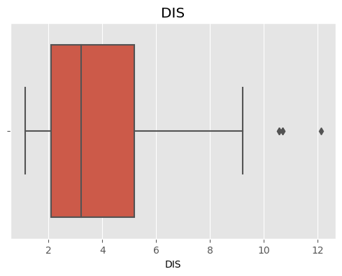

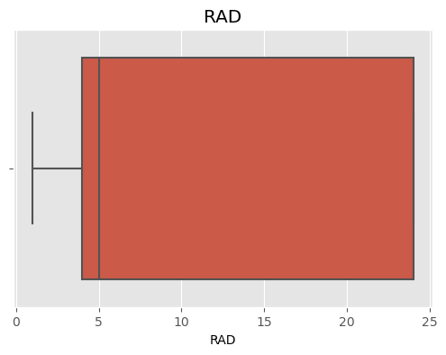

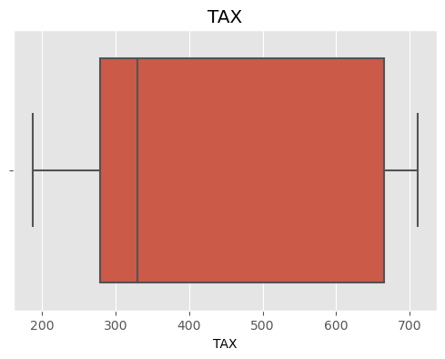

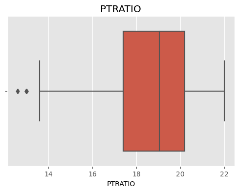

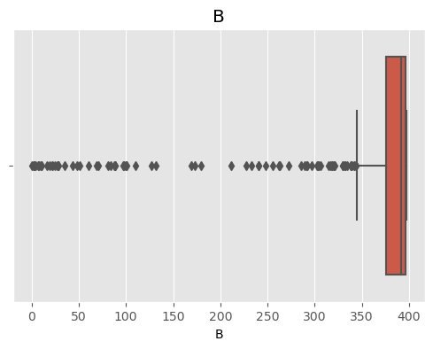

[2 more figures not shown]

```python
cols = ['CRIM', 'ZN', 'INDUS', 'CHAS', 'NOX', 'RM', 'AGE', 'DIS', 'RAD', 'TAX', 'PTRATIO', 'B', 'LSTAT', 'MEDV']

for i in cols:
    fig, ax = plt.subplots(figsize=(6, 4))
    sns.boxplot(x=df[i])
    ax.set_title(i)
    plt.show()
```

# INSIGHTS

### 1) Distribution of Median value of owner-occupied homes

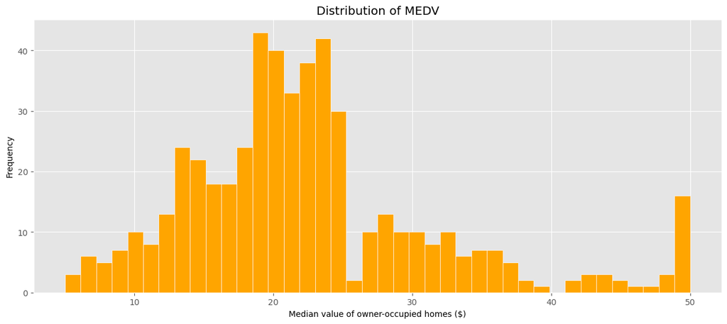

```python
plt.figure(figsize=(15,6))
plt.hist(df["MEDV"], bins=40, color = 'orange', edgecolor = 'white')
plt.xlabel("Median value of owner-occupied homes ($)")
plt.ylabel("Frequency")
plt.title("Distribution of MEDV")
plt.show()
```

##### The median value of owner-occupied homes (MEDV) ranges from around 5,000 to 50,000, with the majority of the values clustered around 20,000.

### 2) Distribution of Average Number of Rooms

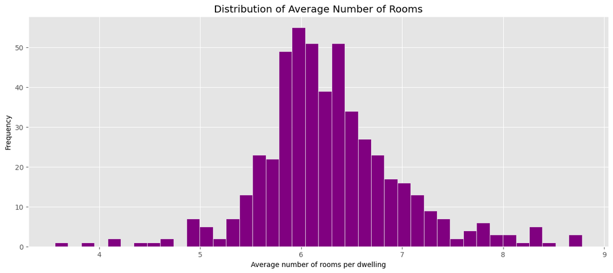

```python
plt.figure(figsize=(15,6))
plt.hist(df['RM'], bins=40, color='purple',edgecolor = 'white')
plt.xlabel('Average number of rooms per dwelling')
plt.ylabel('Frequency')
plt.title('Distribution of Average Number of Rooms')
plt.show()
```

##### The average number of rooms per dwelling (RM) has a relatively normal distribution, with the majority of the values clustering around 6.

### 3) Distribution of LSTAT

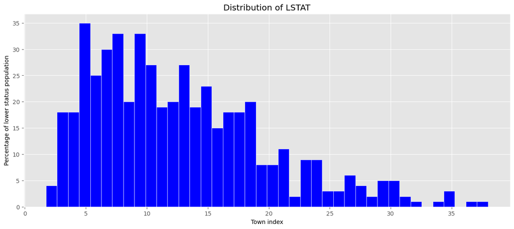

```python
plt.figure(figsize=(15,6))
plt.hist(df['LSTAT'], bins = 40, color='blue', edgecolor = 'white')
plt.title('Distribution of LSTAT')
plt.xlabel('Town index')
plt.ylabel('Percentage of lower status population')
plt.show()
```

##### The percentage of lower status population (LSTAT) has a right-skewed distribution, indicating that most of the towns have a relatively low percentage of lower status population.

### 4) Average CRIM Rate vs RAD

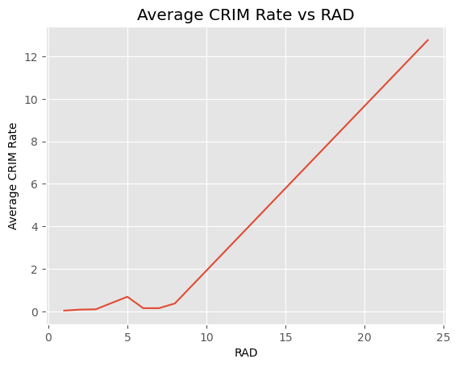

```python
rad_group = df.groupby(['RAD']).agg({'CRIM': np.mean})
plt.plot(rad_group.index, rad_group['CRIM'])
plt.title('Average CRIM Rate vs RAD')
plt.xlabel('RAD')
plt.ylabel('Average CRIM Rate')
plt.show()
```

##### From the line graph, we can observe that there is a general trend of increasing mean CRIM rate as RAD increases

### 5) Average NOX Rate vs RAD

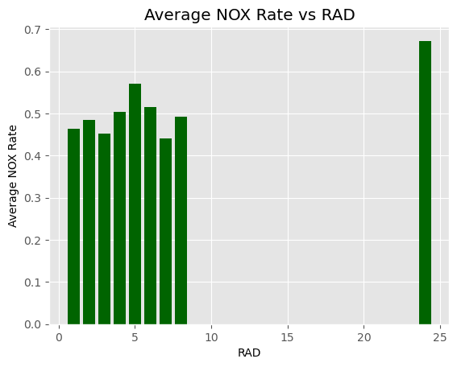

```python
nox_group = df.groupby(['RAD']).agg({'NOX': np.mean})
plt.bar(nox_group.index, nox_group['NOX'], color='darkgreen')
plt.title('Average NOX Rate vs RAD')
plt.xlabel('RAD')
plt.ylabel('Average NOX Rate')
plt.show()
```

### 6) Average MEDV by CHAS

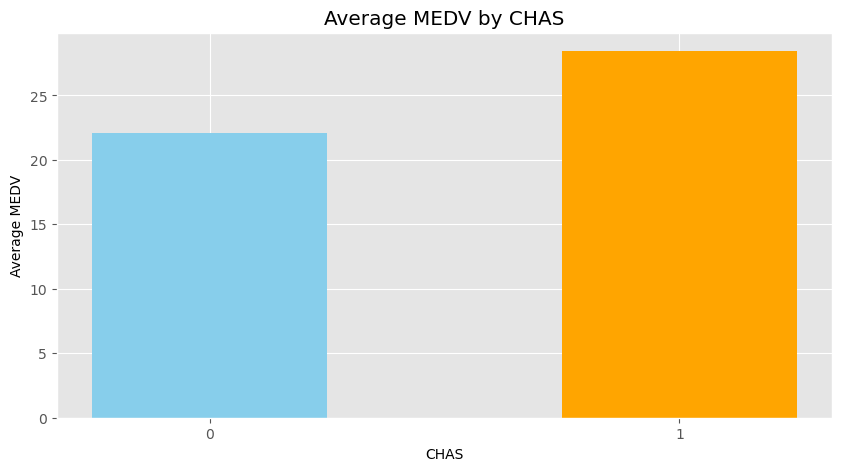

```python
chas_group = df.groupby(['CHAS']).agg({'MEDV': np.mean})
plt.figure(figsize=(10,5))
plt.bar(chas_group.index, chas_group['MEDV'], color=['skyblue', 'orange'], width= 0.5)
plt.title('Average MEDV by CHAS')
plt.xlabel('CHAS')
plt.ylabel('Average MEDV')
plt.xticks([0, 1], ['0', '1'])
plt.show()
```

##### From graph we can see that the MEDV: Median value of owner-occupied home is more where Charles River dummy variable is 1. Which means where ever Charles river is present, the MEDV is higher

## NOX Value and CRIM Rate

#### Making new column NOX_Category in which there are going to be 3 values - Low, Medium, High according to the NOX value

```python
bins = [0, 0.4, 0.6, 1]
df['NOX_Category'] = pd.cut(df['NOX'], bins, labels=['Low', 'Medium', 'High'])
```

```python
df
```

|  | CRIM | ZN | INDUS | CHAS | NOX | RM | AGE | DIS | RAD | TAX | PTRATIO | B | LSTAT | MEDV | NOX_Category |
| --- | --- | --- | --- | --- | --- | --- | --- | --- | --- | --- | --- | --- | --- | --- | --- |
| 0 | 0.00632 | 18.0 | 2.31 | 0 | 0.538 | 6.575 | 65.2 | 4.0900 | 1 | 296.0 | 15.3 | 396.90 | 4.98 | 24.0 | Medium |
| 1 | 0.02731 | 0.0 | 7.07 | 0 | 0.469 | 6.421 | 78.9 | 4.9671 | 2 | 242.0 | 17.8 | 396.90 | 9.14 | 21.6 | Medium |
| 2 | 0.02729 | 0.0 | 7.07 | 0 | 0.469 | 7.185 | 61.1 | 4.9671 | 2 | 242.0 | 17.8 | 392.83 | 4.03 | 34.7 | Medium |
| 3 | 0.03237 | 0.0 | 2.18 | 0 | 0.458 | 6.998 | 45.8 | 6.0622 | 3 | 222.0 | 18.7 | 394.63 | 2.94 | 33.4 | Medium |
| 4 | 0.06905 | 0.0 | 2.18 | 0 | 0.458 | 7.147 | 54.2 | 6.0622 | 3 | 222.0 | 18.7 | 396.90 | 5.33 | 36.2 | Medium |
| ... | ... | ... | ... | ... | ... | ... | ... | ... | ... | ... | ... | ... | ... | ... | ... |
| 501 | 0.06263 | 0.0 | 11.93 | 0 | 0.573 | 6.593 | 69.1 | 2.4786 | 1 | 273.0 | 21.0 | 391.99 | 9.67 | 22.4 | Medium |
| 502 | 0.04527 | 0.0 | 11.93 | 0 | 0.573 | 6.120 | 76.7 | 2.2875 | 1 | 273.0 | 21.0 | 396.90 | 9.08 | 20.6 | Medium |
| 503 | 0.06076 | 0.0 | 11.93 | 0 | 0.573 | 6.976 | 91.0 | 2.1675 | 1 | 273.0 | 21.0 | 396.90 | 5.64 | 23.9 | Medium |
| 504 | 0.10959 | 0.0 | 11.93 | 0 | 0.573 | 6.794 | 89.3 | 2.3889 | 1 | 273.0 | 21.0 | 393.45 | 6.48 | 22.0 | Medium |
| 505 | 0.04741 | 0.0 | 11.93 | 0 | 0.573 | 6.030 | 80.8 | 2.5050 | 1 | 273.0 | 21.0 | 396.90 | 7.88 | 11.9 | Medium |

506 rows × 15 columns

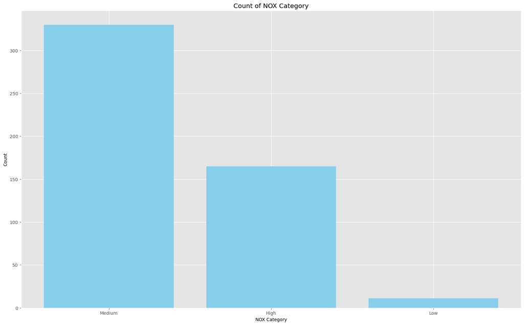

```python
counts = df['NOX_Category'].value_counts()
plt.figure(figsize = (20,12))
plt.bar(counts.index, counts.values, color = 'skyblue')
plt.title('Count of NOX Category')
plt.xlabel('NOX Category')
plt.ylabel('Count')
plt.show()
```

```python
counts
```

```
Medium    330
High      165
Low        11
Name: NOX_Category, dtype: int64
```

### 7) High NOX Value and CRIM Rate

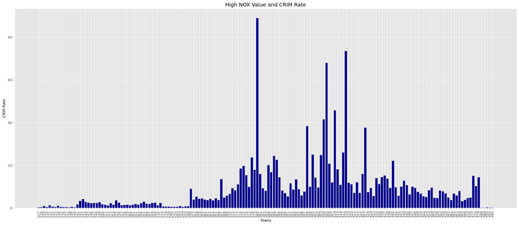

```python
high_nox_crim = df[(df['NOX_Category'] == 'High') & (df['CRIM'] > 0)]

plt.figure(figsize=(25,10))
plt.bar(np.arange(len(high_nox_crim)), high_nox_crim['CRIM'], color = 'darkblue')
plt.xticks(np.arange(len(high_nox_crim)), high_nox_crim.index, rotation=90)
plt.xlabel('Towns')
plt.ylabel('CRIM Rate')
plt.title('High NOX Value and CRIM Rate')
plt.show()
```

### 8) Low NOX Value and CRIM Rate

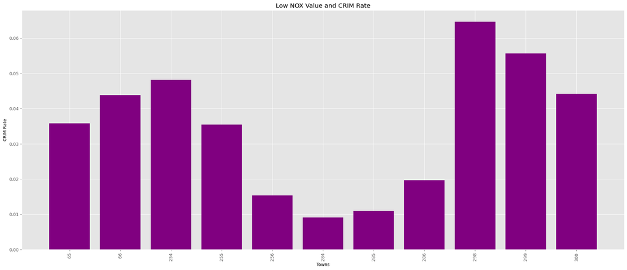

```python
low_nox_crim = df[(df['NOX_Category'] == 'Low') & (df['CRIM'] > 0)]

plt.figure(figsize=(25,10))
plt.bar(np.arange(len(low_nox_crim)), low_nox_crim['CRIM'], color = 'purple')
plt.xticks(np.arange(len(low_nox_crim)), low_nox_crim.index, rotation=90)
plt.xlabel('Towns')
plt.ylabel('CRIM Rate')
plt.title('Low NOX Value and CRIM Rate')
plt.show()
```

### 9) INDUS variable distribution

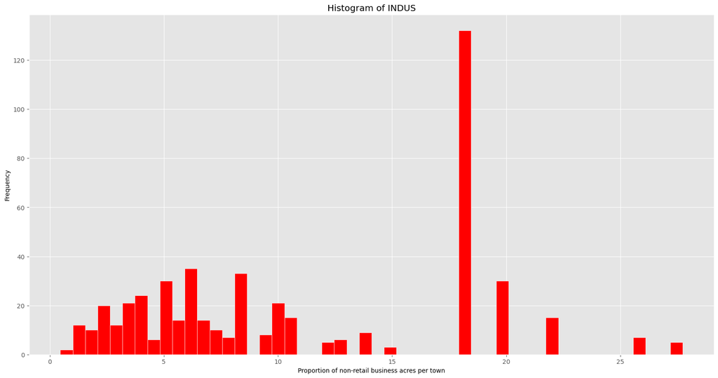

```python
plt.figure(figsize = (20,10))
plt.hist(df['INDUS'], bins=50, edgecolor = 'white', color = 'red')
plt.xlabel('Proportion of non-retail business acres per town')
plt.ylabel('Frequency')
plt.title('Histogram of INDUS')
plt.show()
```

##### From the histogram of INDUS, we can see that the majority of towns have a proportion of non-retail business acres between 5% and 20%. There are relatively few towns with very low (less than 2.5%) or very high (more than 27.5%) values of INDUS.

##### 10) Mean INDUS by RAD

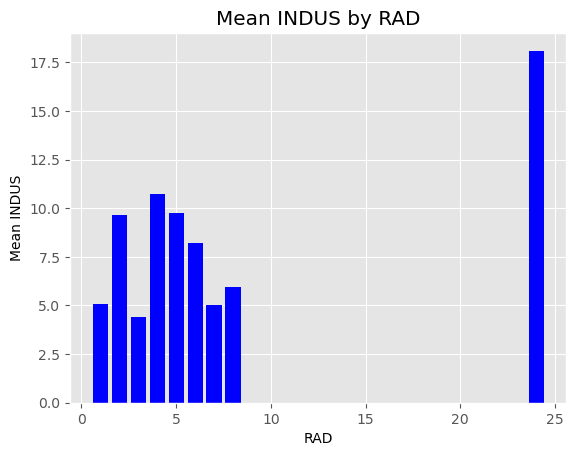

```python
indus_by_rad = df.groupby('RAD')['INDUS'].mean()

plt.bar(indus_by_rad.index, indus_by_rad.values, color = 'blue')
plt.xlabel('RAD')
plt.ylabel('Mean INDUS')
plt.title('Mean INDUS by RAD')
plt.show()
```

##### 11) Heat map

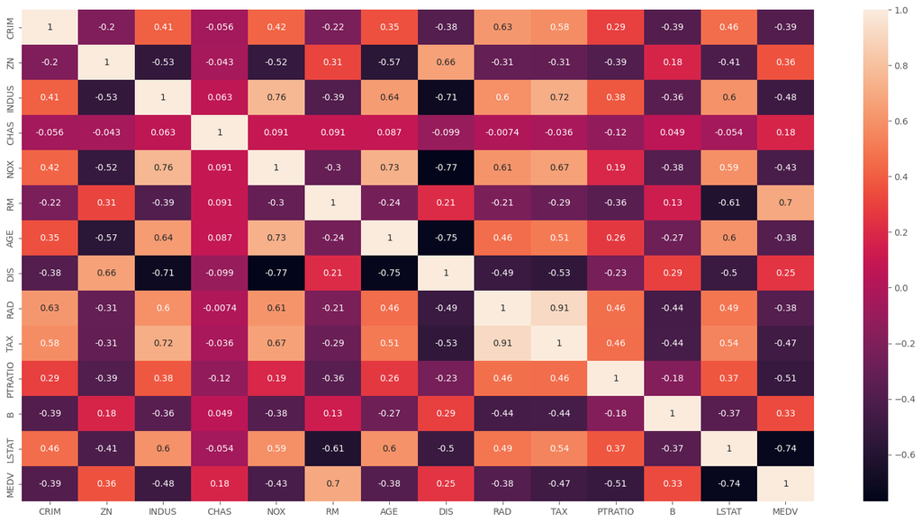

```python
plt.figure(figsize = (20,10))
sns.heatmap(df.corr(numeric_only=True), annot=True)
```

OBSERVATION:

1) The strongest positive correlation is between RAD and TAX, which indicates that the areas with high accessibility to radial highways also tend to have higher property tax rates.

2) There is a strong negative correlation between DIS and both NOX and AGE. This suggests that the further away a property is from the employment centers, the lower the concentration of nitrogen oxides in the air and the newer the properties in the area.

3) There is a moderate positive correlation between RM and MEDV, which suggests that the median value of owner-occupied homes tends to increase with the average number of rooms per dwelling.

4) There is a moderate negative correlation between LSTAT and MEDV, which suggests that areas with a higher percentage of lower status of the population tend to have lower median home values.

6) There is a weak negative correlation between CRIM and both RM and MEDV, which indicates that areas with higher crime rates tend to have lower home values and fewer rooms per dwelling.

7) Overall, this heatmap can provide valuable insights into the relationships between different variables in the dataset, which can be helpful for making informed decisions related to real estate investments or policy-making.